# Coursework Report

*N* removed NAs: 2

*N* removed typo: 1

*N* removed <18: 20

*N* total clean: 128

| Group | *N* | *M*<sub>age</sub> | *M*<sub>rating</sub> |
| --- | --- | --- | --- |
| Control | 65 | 20.65 | 5.44 |
| Experim | 63 | 20.32 | 6.69 |

**Main analysis results**

*t*(126) = -10.03, *p* < .001

[interactive chart not shown]

[figure not shown]

[interactive chart not shown]

# Coursework Report

Analysing Data, Spring 2020

# Methods

## Participants

150 people participated in the initial experiment. The mean of the participants’ ages is 20.48, the standard deviation is 1.67, and the participants’ age range is from 18 to 25 years.  
22 people were removed from the data set due to reasons such as participants being of an unethical age (under 18s), or from entering invalid data into the questionnaire, rendering their data unusable.  
Therefore, the final number of people whose data is included in the results is 128 participants – 65 in the Control condition and 63 in the Experimental condition.

| Condition | n | perc | mean_age | sd_age |
| --- | --- | --- | --- | --- |
| Control | 65 | 50.78125 | 20.64615 | 1.690329 |
| Experimental | 63 | 49.21875 | 20.31746 | 1.644398 |

*Table 1. Participant descriptives by experimental condition.*

## Design

Throughout this study, researchers conducted an experiment to investigate the hypothesis that red strengthens the attraction of women to men namely by increasing the woman’s view of the man’s position, which strengthens her attraction to him, this research extending from the works of Elliot et al (2010). This study will therefore examine the effect of the colours red and white on women’s perceptions of the attractiveness of a man (Elliot et al., 2010, p 403).

One variable that will be uses in the analysis is the Colour Condition that the participants will be subjected to, done through a black-and-white photograph of a man placed on a White background (Control group) or on a Red background (Experimental group). This study thereby involves an independent measures/ between groups design.

The other variable is the Rating of Attractiveness, where the participants use a 9-point Likert rating scale whilst answering 3 questions about the perceived attractiveness of the photographed man, such as “How attractive do you think this person is?”, “How pleasant is this person to look at?” and “If I were to meet the person in this picture face to face, I would think he is attractive.” . The Likert scale will range from 1 – *not at all attractive* – to 9 (*extremely attractive*) (Elliot et al., 2010, p 403), this being how the variable will be measured and interpreted in analysis.

The operational hypothesis is that the participants in the Red Colour Condition (experimental) will perceive and score the man higher in the Mean Rating of Attractiveness than participants in the White Colour Condition (control). To test this, statistical analysis such as a *T*-Test will be conducted.

# Results

The results present that the Red experimental group had an overall mean Rating of Attractiveness of 6.69 (sd 1.25), whereas the White control group had on overall mean of 5.44 (sd 1.34).

| Condition | mean_Item_1 | sd_Item_1 | mean_Item_2 | sd_Item_2 | mean_Item_3 | sd_Item_3 |
| --- | --- | --- | --- | --- | --- | --- |
| Control | 5.600000 | 1.367022 | 5.569231 | 1.345934 | 5.138462 | 1.297557 |
| Experimental | 6.777778 | 1.197369 | 6.492064 | 1.255607 | 6.809524 | 1.305783 |

*Table 2. The summary of the data presenting the means and standard deviations counts in each condition.*

The statistical test that was conducted was a *T*-Test:

```
##
##  Two Sample t-test
##
## data:  Attraction by Condition
## t = -10.026, df = 126, p-value < 0.00000000000000022
## alternative hypothesis: true difference in means is not equal to 0
## 95 percent confidence interval:
##  -1.505377 -1.009071
## sample estimates:
##      mean in group Control mean in group Experimental
##                   5.435897                   6.693122
```

Thus, the P-value is less than the *a* significance level, so the null hypothesis is rejected. This implies that the alternative hypothesis is correct, and that the data is significant. Therefore, the participants in the Red Colour Condition (experimental) perceived and scored the man higher in the Mean Rating of Attractiveness than participants in the White Colour Condition (control).

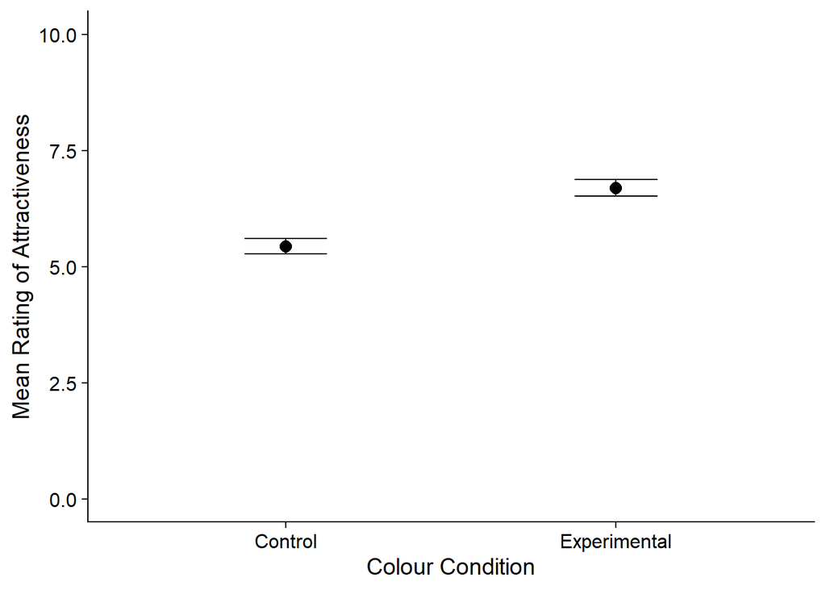

*Figure 1. A graph to show Colour Condition against the Mean Rating of Attractiveness.*

# Discussion

To summarise the results, it was found that the Red Condition participants rated the man as more attractive than the White Condition participants.

Elliot et al (2010) found the Red Condition to have *M* = 6.79 and the White Condition *M* = 5.67 (p. 403) – the present study found *M* = 6.69 and *M* = 5.44, respectively. So, compared to Elliot et al’s original study, the results of the present study are very similar and the patterns of results are almost identical. Therefore, for the effect that was investigated, the present study provides support for the original findings, thereby suggesting that red does strengthen women’s attraction to men and that this is a likely occurence.

Compared to other studies and/ or replication attempts on the same topic, such as Hesslinger, Goldbach & Carbon (2015), they did not find any significant impact of red, even when using Elliot et al’s paradigm. Their findings question the ecological validity of the original study since it was displayed that there was instead a significant effect with attractiveness ratings being higher for men wearing smarter apparel (Hesslinger, Goldbach & Carbon., 2015); therefore, the same questions would apply for the findings of the current study. Another study by Peperkoorn, Roberts & Pollet (2016) also found that with the three experiments they conducted, the red effect was not present by any means (Peperkoorn, Roberts & Pollet., 2016). Hence, the same pattern of results found in Elliot et al’s (2010) research and the current research is not always present in other findings, and may in fact be a contradiction. However, Peperkoorn, Roberts & Pollet’s (2016) studies were based on men’s attraction to women in red, so there may be a difference of the red effect on the opposing sex. This means for the red effect that was currently investigated, the findings are not always fully supported and inconsistencies are present, possibly due to weak ecological validity.

Based on my own analysis and the strengths and limitations of my study, I think that the red effect is real (that red does make men more attractive to women) because I happened to find a very similar pattern of results compared to the original study. So, even with opposing findingd from other researchers, this must give some level of leverage and support for the red effect.

I believe this research question is worth investigating further as it leads to interesting discussions in the field of social psychology. For example, I would suggest that future studies should investigate whether the red effect are presented in a collaborative setting. A study would be conducted with a similar paradigm to Elliot et al (2010), however the participants are sitting in a group setting and discuss what they think about the man’s attractiveness before rating the man’s attractiveness individually. This is because a group mentality to attraction could differ from the individual, and the same could apply towards effects on attraction. Another suggestion would be to investigate whether the red effect is present when using a physical male model instead of a photograph. The presence of the male may produce differing effects in their attractiveness to the women. A further suggestion for future research could be to use only participants of differing sexual attraction, since myself and Elliot et al (2010) only involved the rating of participant’s attraction of men in conjunction with red, by woman. Thus, a woman rating attraction of a woman with red might produce contrasting findings.

To summarise the main findings, my study supports the original study conducted by Elliot et al (2010) due to comparable results being produced, so the red effect is evident. However, differing research points towards the red effect not being as evident as previously thought.

# References

**Bibliography**

Elliot, A. J., Greitemeyer, T., Gramzow, R. H., Niesta Kayser, D., Lichtenfeld, S., & Maier, M. A. (2010). Red, Rank, and Romance in Women Viewing Men. *Journal of Experimental Psychology: General*, 139(3), 399 – 417. DOI: 10.1037/a0019689.

Hesslinger, V. M., Goldbach, L., & Carbon, C.-C. (2015, June 17). Men in Red: A Reexamination of the Red-Attractiveness Effect. *Psychonomic Bulletin & Review*, 1142–1148. https://doi.org/10.3758/s13423-015-0866-8.

Peperkoorn, L. S., Roberts, S. C., & Pollet, T. V. (2016). Revisiting the Red Effect on Attractiveness and Sexual Receptivity: No Effect of the Color Red on Human Mate Preferences. *Evolutionary Psychology*, 1-11. https://doi.org/10.1177/1474704916673841.